# Getting started with edr4r

`edr4r` is a small, tidy client for any service that speaks [OGC API - Environmental Data Retrieval](https://ogcapi.ogc.org/edr/). Most of the real-world use to date has been against in-situ monitoring networks – stream gauges, weather stations, snow telemetry, reservoir telemetry – but the package itself is generic.

Two example endpoints you can point it at right now:

- [USGS waterdata OGC API](https://api.waterdata.usgs.gov/ogcapi/beta/)
- [Western Water Datahub](https://api.wwdh.internetofwater.app)

This vignette runs end-to-end against the Western Water Datahub’s `rise-edr` collection – a [pygeoapi](https://pygeoapi.io) wrap of USBR’s reservoir telemetry. The USGS example lives in its own article, `vignette("usgs-streamgages")`.

## 1. Create a client

```r
library(edr4r)
library(ggplot2)

client <- edr_client("https://api.wwdh.internetofwater.app")
client
```

```
#> <edr_client>
#>   base_url:   <https://api.wwdh.internetofwater.app>
#>   user_agent: edr4r/0.1.0 (+https://github.com/ksonda/edr4r)
#>   timeout:    60s
#>   max_tries:  3
```

The client just stores connection settings (base URL, user agent, timeout, retry policy). Pass `verbose = TRUE` to echo every request URL, or `headers =` to attach auth tokens.

## 2. Discover collections and parameters

`edr_collections()` lists every EDR collection the service serves.

```r
collections <- edr_collections(client)
collections[, c("id", "title", "data_queries")]
```

```
#> # A tibble: 35 × 3
#>    id                 title                                         data_queries
#>    <chr>              <chr>                                         <list>
#>  1 rise-edr           USBR Reclamation Information Sharing Environ… <chr [4]>
#>  2 snotel-edr         USDA Snowpack Telemetry Network (SNOTEL)      <chr [4]>
#>  3 awdb-forecasts-edr USDA Air and Water Database (AWDB) Forecasts  <chr [4]>
#>  4 snotel-huc06-means USDA Snotel Snow Water Equivalent Aggregated… <NULL>
#>  5 usace-edr          USACE Access2Water API                        <chr [4]>
#>  6 noaa-qpf-day-1     NOAA Weather Prediction Center Quantitative … <NULL>
#>  7 noaa-qpf-day-2     NOAA Weather Prediction Center Quantitative … <NULL>
#>  8 noaa-qpf-day-3     NOAA Weather Prediction Center Quantitative … <NULL>
#>  9 noaa-qpf-day-4-5   NOAA Weather Prediction Center Quantitative … <NULL>
#> 10 noaa-qpf-day-6-7   NOAA Weather Prediction Center Quantitative … <NULL>
#> # ℹ 25 more rows
```

The `data_queries` column tells you which EDR query types each collection supports (`locations`, `cube`, `area`, …). Hit a verb the server doesn’t implement and you get an HTTP error.

To see the data parameters a collection exposes (the values you can pass to `parameter_name =` on the query verbs), use `edr_parameters()`:

```r
params <- edr_parameters(client, "rise-edr")
nrow(params)
```

```
#> [1] 782
```

```r
head(params[, c("id", "name", "unit_symbol")])
```

```
#> # A tibble: 6 × 3
#>   id    name                                             unit_symbol
#>   <chr> <chr>                                            <chr>
#> 1 1835  Secondary Canal Stage                            ft
#> 2 1834  Lake/Reservoir Elevation                         ft
#> 3 1830  Lake/Reservoir Release - Total                   cfs
#> 4 1818  Total Dissolved Gas (TDG)                        %
#> 5 1817  Growing Degree Days (50 Degree Base Temperature) GDD
#> 6 1816  Calculated Unregulated Flow                      taf
```

`edr_queryables()` is something different – it returns the OGC queryables JSON Schema (filter properties for CQL2 / OGC API Features). For discovering parameter names, `edr_parameters()` is what you want.

```r
# Pick out the daily reservoir storage parameter (id "3"):
params[params$id == "3", c("id", "name", "unit_symbol", "unit_label")]
```

```
#> # A tibble: 1 × 4
#>   id    name                              unit_symbol unit_label
#>   <chr> <chr>                             <chr>       <chr>
#> 1 3     Daily Lake/Reservoir Storage (af) acre·ft     Acre Foot
```

## 3. Find locations

With no filters, `edr_locations()` returns the station index as a GeoJSON `FeatureCollection`, promoted to an `sf` object when [`sf`](https://r-spatial.github.io/sf/) is installed:

```r
stations <- edr_locations(client, "rise-edr")
nrow(stations)
```

```
#> [1] 906
```

```r
head(stations[, c("_id", "locationName")])
```

```
#> Simple feature collection with 6 features and 2 fields
#> Geometry type: POINT
#> Dimension:     XY
#> Bounding box:  xmin: -122.474 ymin: 32.8834 xmax: -101.2656 ymax: 48.2667
#> Geodetic CRS:  WGS 84
#> # A tibble: 6 × 3
#>   `_id` locationName                                      geometry
#>   <int> <chr>                                          <POINT [°]>
#> 1     1 Marys Lake                            (-105.5343 40.34408)
#> 2     2 Audubon Lake North Dakota              (-101.2656 47.6114)
#> 3     3 Gray Reef Reservoir and Dam            (-106.6989 42.5656)
#> 4     5 Lake Frances Reservoir                    (-112.2 48.2667)
#> 5     6 Spring Creek Reservoir and Debris Dam    (-122.474 40.629)
#> 6     7 Imperial Reservoir at Imperial Dam     (-114.4676 32.8834)
```

The WWDH `rise-edr` locations index uses `_id` as the identifier column, not `id`. That’s fine – the query verbs accept either, and `edr_map()` will auto-detect.

## 4. Retrieve data for one station

Pick a known station (Lake Mead, `_id` 3514) and a parameter (`3`, Daily Reservoir Storage) and you get CoverageJSON back. Flatten it with `covjson_to_tibble()`:

```r
resp <- edr_location(
  client, "rise-edr",
  location_id    = 3514,
  datetime       = "2023-01-01/2023-06-30",
  parameter_name = "3"
)

df <- covjson_to_tibble(resp)
head(df)
```

```
#> # A tibble: 6 × 9
#>   coverage_id parameter parameter_label    unit  datetime                x     y
#>   <chr>       <chr>     <chr>              <chr> <dttm>              <dbl> <dbl>
#> 1 1           3         Lake/Reservoir St… af    2023-01-01 07:00:00 -115.  36.0
#> 2 1           3         Lake/Reservoir St… af    2023-01-02 07:00:00 -115.  36.0
#> 3 1           3         Lake/Reservoir St… af    2023-01-03 07:00:00 -115.  36.0
#> 4 1           3         Lake/Reservoir St… af    2023-01-04 07:00:00 -115.  36.0
#> 5 1           3         Lake/Reservoir St… af    2023-01-05 07:00:00 -115.  36.0
#> 6 1           3         Lake/Reservoir St… af    2023-01-06 07:00:00 -115.  36.0
#> # ℹ 2 more variables: z <dbl>, value <dbl>
```

## 5. Plot the time series

`edr_plot()` is a small `ggplot2` wrapper for the tidy tibble:

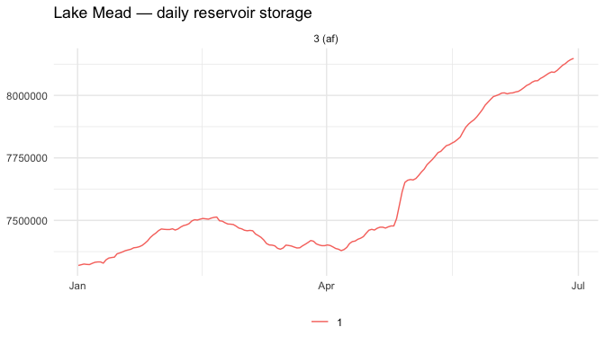

```r
edr_plot(resp) +
  ggtitle("Lake Mead — daily reservoir storage")
```

Faceted by parameter (so different units don’t share a y-axis) and coloured by station. Add layers or themes like any other ggplot.

## 6. Map stations with per-station popups

For collections that support `cube`, `edr_explore()` fetches every station’s data in **one** bulk request and renders the map with per-station popups – much faster than fetching one station at a time. `rise-edr` advertises `cube`, so the default `method = "auto"` takes that path.

```r
m <- edr_explore(
  client, "rise-edr",
  bbox           = c(-114, 32, -111, 38),         # SW US
  datetime       = "2023-01-01/2023-06-30",
  parameter_name = "3",
  popup          = "plot+csv",
  label_col      = "locationName",
  quiet          = TRUE
)
# Embed the interactive map inline via a base64 data URI so the vignette
# is fully selfcontained (no sidecar files in inst/doc/).
tmp <- tempfile(fileext = ".html")
edr_save_html(m, tmp)
data_uri <- paste0(
  "data:text/html;charset=utf-8;base64,",
  base64enc::base64encode(tmp)
)
unlink(tmp)
cat(sprintf(
  '<iframe src="%s" width="100%%" height="520" style="border:1px solid #ddd;"></iframe>',
  data_uri
))
```

[interactive chart not shown]

Markers with data are blue (clickable popup with plot + CSV); stations the bbox covers that returned no data for the requested parameter/window are dimmed grey. A legend in the bottom-right explains the distinction.

Save the same map to standalone HTML (selfcontained, no sidecar directory):

```r
edr_save_html(m, "wwdh-southwest.html")
```

## A few things worth knowing

- `datetime` is forgiving: pass `"start/end"`, an open interval like `"2020-01-01/.."`, or a length-2 character vector. It gets normalised into the ISO-8601 form the server expects.
- `parameter_name` is a character vector. It’s sent as one comma-separated `parameter-name` query parameter.
- Some monitoring networks use compound station IDs (colon-separated triplets like `"1185:CO:SNTL"` show up in snow and forecast networks). Those work as-is – reserved characters get URL-encoded for you. A literal `/` in an ID is rejected, because it can’t survive a round trip through HTTP path segments no matter how you encode it.
- Not every server implements every EDR verb. `locations`, `position`, `cube`, and `area` are common; `radius`, `trajectory`, and `corridor` less so. The client supports them all per the [spec](https://ogcapi.ogc.org/edr/), but a call against a collection that doesn’t implement a given verb returns an HTTP error.

## See also

- `vignette("usgs-streamgages")` – a walk-through against the USGS waterdata endpoint, which only advertises `locations` (so the per-station fallback kicks in).